# Peer Assessment II

**Background and setup**

As a statistical consultant working for a real estate investment firm, your task is to develop a model to predict the selling price of a given home in Ames, Iowa. Your employer hopes to use this information to help assess whether the asking price of a house is higher or lower than the true value of the house. If the home is undervalued, it may be a good investment for the firm.

In order to better assess the quality of the model you will produce, the data have been randomly divided into three separate pieces: a training data set, a testing data set, and a validation data set. For now we will load the training data set, the others will be loaded and used later.

```r
load("ames_train.Rdata")
```

Use the code block below to load any necessary packages.

```r
library(statsr)
library(tidyverse)
library(BAS)
library(MASS)
library(gridExtra)
library(GGally)
```

# 1 Exploratory Data Analysis (EDA)

When you first get your data, it’s very tempting to immediately begin fitting models and assessing how they perform. However, before you begin modeling, it’s absolutely essential to explore the structure of the data and the relationships between the variables in the data set.

Do a detailed EDA of the ames_train data set, to learn about the structure of the data and the relationships between the variables in the data set (refer to Introduction to Probability and Data, Week 2, for a reminder about EDA if needed). Your EDA should involve creating and reviewing many plots/graphs and considering the patterns and relationships you see.

After you have explored completely, submit the three graphs/plots that you found most informative during your EDA process, and briefly explain what you learned from each (why you found each informative).

Let us clean some of the variables in the model.

```r
# Cleaning.

# Change the categorical variables that have been coded as numerical back into categorical.
ames_train$Overall.Cond <- factor(ames_train$Overall.Cond, ordered = TRUE)
ames_train$Overall.Qual <- factor(ames_train$Overall.Qual, ordered = TRUE)

# Convert all NA's of Total.Bsmt.SF and Garage.Area into 0.
ames_train$Total.Bsmt.SF <- replace_na(ames_train$Total.Bsmt.SF, 0)
ames_train$Garage.Area <- replace_na(ames_train$Garage.Area, 0)

# Convert NA values in Garage.Qual into a separate level "NoG" meaning "No Garage".
ames_train$Garage.Qual <- fct_explicit_na(ames_train$Garage.Qual, na_level = "NoG")
```

Let us start by looking at co-linearity between some of the numerical continuous predictor variables.

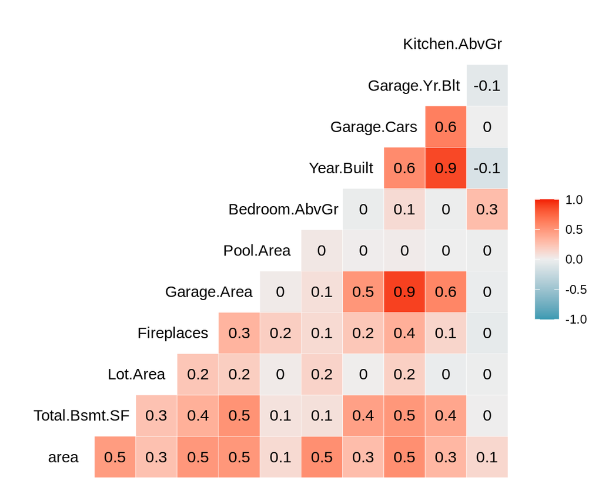

```r
# Subset the data set to include required variables.
ames_train_subset <- ames_train %>% dplyr::select(area, Total.Bsmt.SF, Lot.Area,
                Fireplaces, Garage.Area, Pool.Area, Bedroom.AbvGr, Year.Built,
                Garage.Cars, Garage.Yr.Blt, Kitchen.AbvGr)

# Display correlations.
ggcorr(ames_train_subset, hjust = .85, layout.exp = 1, label = TRUE)
```

We can see that the variables **Garage.Area** and **Garage.Cars** are highly correlated with $R = .9$. Similarly, the variables **Year.Built** and **Garage.Yr.Blt** are correlated with a $R=.9$. Including both from each pair would give rise to multi-colinearity. Therefore, one of the variables from each pair should not be included when modelling.

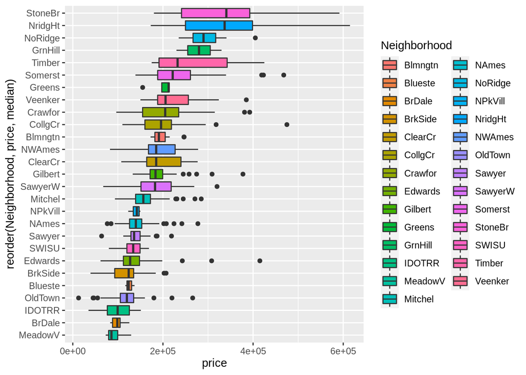

```r
# price and Neighborhood
ggplot(data = ames_train, aes(x = reorder(Neighborhood, price, median), y = price, fill = Neighborhood)) +
  geom_boxplot() + coord_flip()
```

It is clear that **Neighborhood** is a good predictor for **price** because the median price varies with respect to the neighborhood. This is not surprising because this is the expected behavior. Therefore, **Neighborhood** should be included in the model.

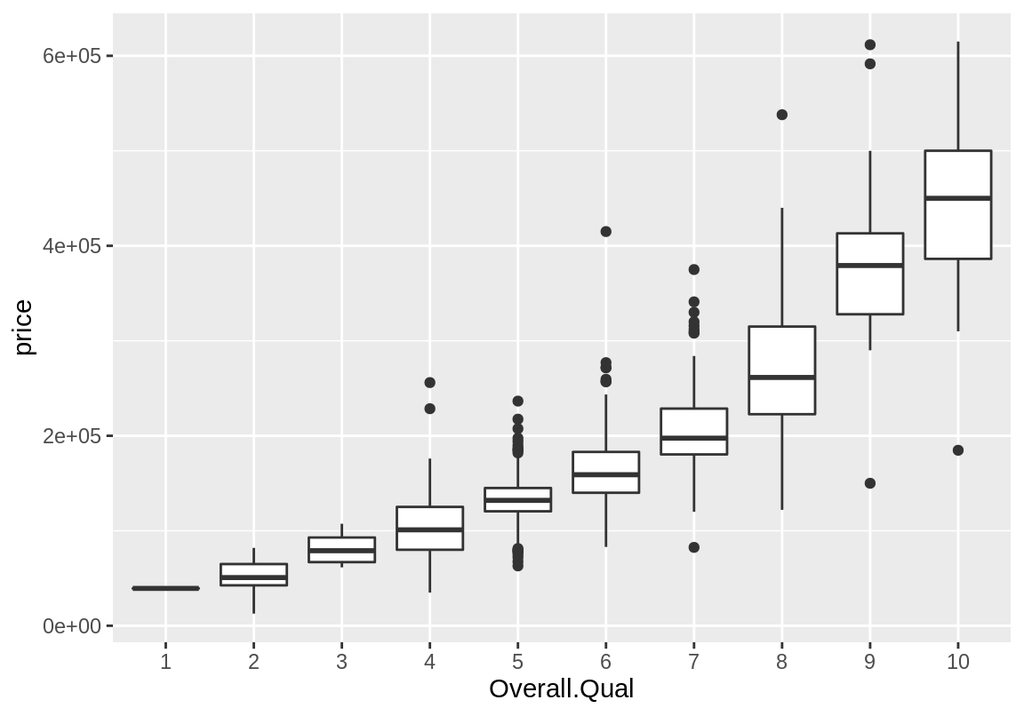

```r
ggplot(data = ames_train, aes(x = Overall.Qual, y = price)) + geom_boxplot()
```

According to the above chart, there seems to be a positive association between the overall quality rating of the house with its sale price. Again, this is the expected observation i.e. high quality houses would be sold at a higher price. Consequently, **Overall.Qual** should be included in the model.

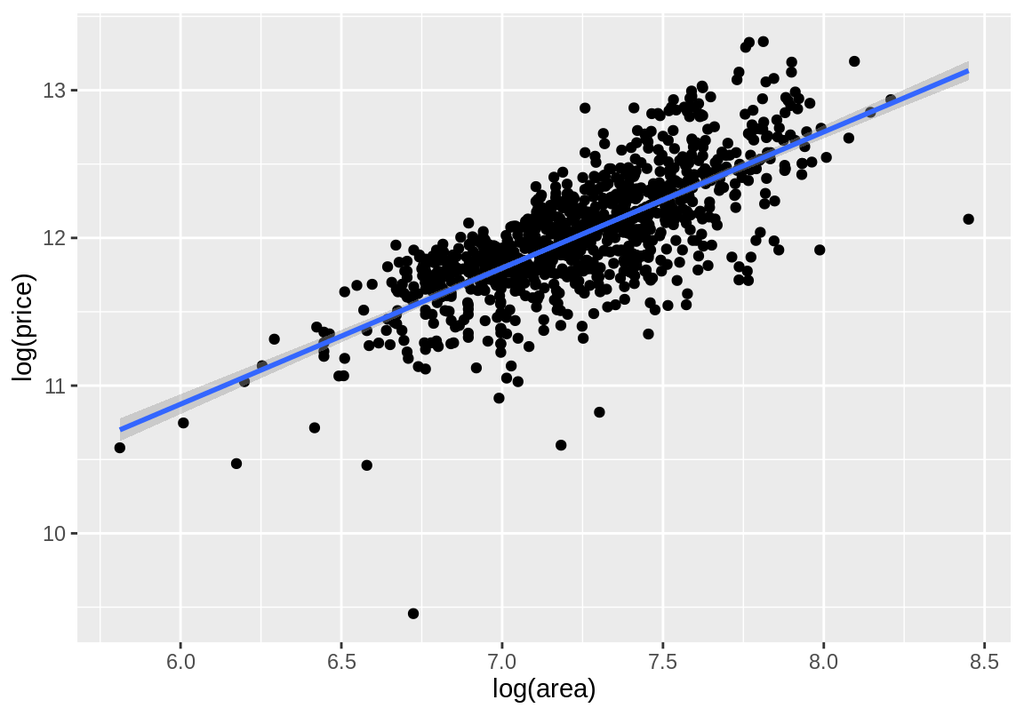

```r
ggplot(data = ames_train, aes(x = log(area), y = log(price))) +
  geom_point() + geom_smooth(formula = y ~ x, method='lm')
```

Most numerical continuous variables in the data set are skewed (mostly right skewed). Therefore, in order to make them more suitable for regression, they should be log transformed. In the above chart, I have plotted **log(price)** vs. **log(area)**. There is a good positive association between the two variables. Therefore, **area** could be a good predictor of the **price**.

# 2 Development and assessment of an initial model

## 2.1 An Initial Model

In building a model, it is often useful to start by creating a simple, intuitive initial model based on the results of the exploratory data analysis. (Note: The goal at this stage is **not** to identify the “best” possible model but rather to choose a reasonable and understandable starting point. Later you will expand and revise this model to create your final model.

Based on your EDA, select *at most* 10 predictor variables from “ames_train” and create a linear model for `price` (or a transformed version of price) using those variables. Provide the *R code* and the *summary output table* for your model, a *brief justification* for the variables you have chosen, and a *brief discussion* of the model results in context (focused on the variables that appear to be important predictors and how they relate to sales price).

```r
# Initial model.
model1 <- lm(log(price) ~ log(area) + Neighborhood + Overall.Qual + Year.Built +
             Garage.Area + Lot.Area + Bedroom.AbvGr, data = ames_train)

summary(model1)
```

```
##
## Call:
## lm(formula = log(price) ~ log(area) + Neighborhood + Overall.Qual +
##     Year.Built + Garage.Area + Lot.Area + Bedroom.AbvGr, data = ames_train)
##
## Residuals:
##      Min       1Q   Median       3Q      Max
## -1.42593 -0.07014  0.00628  0.08116  0.74506
##
## Coefficients:
##                       Estimate Std. Error t value Pr(>|t|)
## (Intercept)          1.776e+00  8.591e-01   2.067  0.03897 *
## log(area)            4.690e-01  2.842e-02  16.503  < 2e-16 ***
## NeighborhoodBlueste -1.566e-01  1.054e-01  -1.486  0.13761
## NeighborhoodBrDale  -2.990e-01  7.230e-02  -4.136 3.85e-05 ***
## NeighborhoodBrkSide  2.771e-02  6.238e-02   0.444  0.65703
## NeighborhoodClearCr  9.304e-02  7.030e-02   1.324  0.18598
## NeighborhoodCollgCr  2.206e-02  5.198e-02   0.424  0.67142
## NeighborhoodCrawfor  1.861e-01  6.128e-02   3.037  0.00246 **
## NeighborhoodEdwards -4.099e-02  5.632e-02  -0.728  0.46691
## NeighborhoodGilbert -1.528e-02  5.447e-02  -0.281  0.77911
## NeighborhoodGreens   5.125e-02  9.556e-02   0.536  0.59189
## NeighborhoodGrnHill  4.022e-01  1.228e-01   3.276  0.00109 **
## NeighborhoodIDOTRR  -1.136e-01  6.364e-02  -1.785  0.07459 .
## NeighborhoodMeadowV -2.006e-01  6.680e-02  -3.003  0.00274 **
## NeighborhoodMitchel  3.763e-02  5.613e-02   0.671  0.50268
## NeighborhoodNAmes    4.422e-02  5.443e-02   0.812  0.41675
## NeighborhoodNoRidge  1.137e-01  5.872e-02   1.936  0.05319 .
## NeighborhoodNPkVill -9.528e-02  9.444e-02  -1.009  0.31327
## NeighborhoodNridgHt  1.194e-01  5.503e-02   2.170  0.03028 *
## NeighborhoodNWAmes   2.119e-02  5.633e-02   0.376  0.70692
## NeighborhoodOldTown -1.638e-02  6.190e-02  -0.265  0.79138
## NeighborhoodSawyer   4.414e-02  5.664e-02   0.779  0.43604
## NeighborhoodSawyerW -4.347e-02  5.490e-02  -0.792  0.42871
## NeighborhoodSomerst  2.841e-02  5.208e-02   0.546  0.58547
## NeighborhoodStoneBr  1.624e-01  6.222e-02   2.610  0.00919 **
## NeighborhoodSWISU    8.486e-03  7.369e-02   0.115  0.90833
## NeighborhoodTimber   7.909e-02  6.213e-02   1.273  0.20335
## NeighborhoodVeenker  1.521e-02  7.147e-02   0.213  0.83154
## Overall.Qual.L       1.094e+00  1.002e-01  10.917  < 2e-16 ***
## Overall.Qual.Q      -1.495e-01  9.093e-02  -1.644  0.10057
## Overall.Qual.C       1.964e-02  8.170e-02   0.240  0.81003
## Overall.Qual^4       6.949e-02  6.598e-02   1.053  0.29252
## Overall.Qual^5      -2.164e-01  4.955e-02  -4.367 1.40e-05 ***
## Overall.Qual^6       9.526e-02  4.049e-02   2.353  0.01884 *
## Overall.Qual^7      -1.119e-01  3.488e-02  -3.207  0.00139 **
## Overall.Qual^8       7.011e-02  2.597e-02   2.700  0.00706 **
## Overall.Qual^9      -3.125e-02  1.542e-02  -2.026  0.04305 *
## Year.Built           3.397e-03  4.121e-04   8.242 5.51e-16 ***
## Garage.Area          1.814e-04  3.223e-05   5.629 2.38e-08 ***
## Lot.Area             3.235e-06  5.825e-07   5.553 3.63e-08 ***
## Bedroom.AbvGr       -3.602e-02  8.701e-03  -4.140 3.78e-05 ***
## ---
## Signif. codes:  0 '***' 0.001 '**' 0.01 '*' 0.05 '.' 0.1 ' ' 1
##
## Residual standard error: 0.1592 on 959 degrees of freedom
## Multiple R-squared:  0.8625, Adjusted R-squared:  0.8568
## F-statistic: 150.5 on 40 and 959 DF,  p-value: < 2.2e-16
```

**Rationale for variables:** All the variables used are important when choosing a house. Therefore, it is natural that they would impact the sale price. For instance, neighborhood is vital. Depending on the location, the sale price of real estate varies widely. Similarly, the area of the house is also crucial. Lot area is the total size of the house plus the garden and drive way. Another important factor in determining the price is the year on which the house was built. Newer houses would be pricier. Similarly, the number of bed rooms and the overall quality would also matter.

**Relationship between some variables and price:** This is through the variable coefficient. For example, all else held constant, the model predicts a 0.47 percent increase in price per log(area) increase. Similarly, all else held constant, the model predicts a 0.036 percent decrease in price per bedroom above grade.

## 2.2 Model Selection

Now either using `BAS` another stepwise selection procedure choose the “best” model you can, using your initial model as your starting point. Try at least two different model selection methods and compare their results. Do they both arrive at the same model or do they disagree? What do you think this means?

```r
# AIC
model1.aic <- stepAIC(model1, trace = FALSE, k = 2)

# BIC
model1.bic <- stepAIC(model1, trace = FALSE, k = log(nrow(ames_train)))

summary(model1.aic)
```

```
##
## Call:
## lm(formula = log(price) ~ log(area) + Neighborhood + Overall.Qual +
##     Year.Built + Garage.Area + Lot.Area + Bedroom.AbvGr, data = ames_train)
##
## Residuals:
##      Min       1Q   Median       3Q      Max
## -1.42593 -0.07014  0.00628  0.08116  0.74506
##
## Coefficients:
##                       Estimate Std. Error t value Pr(>|t|)
## (Intercept)          1.776e+00  8.591e-01   2.067  0.03897 *
## log(area)            4.690e-01  2.842e-02  16.503  < 2e-16 ***
## NeighborhoodBlueste -1.566e-01  1.054e-01  -1.486  0.13761
## NeighborhoodBrDale  -2.990e-01  7.230e-02  -4.136 3.85e-05 ***
## NeighborhoodBrkSide  2.771e-02  6.238e-02   0.444  0.65703
## NeighborhoodClearCr  9.304e-02  7.030e-02   1.324  0.18598
## NeighborhoodCollgCr  2.206e-02  5.198e-02   0.424  0.67142
## NeighborhoodCrawfor  1.861e-01  6.128e-02   3.037  0.00246 **
## NeighborhoodEdwards -4.099e-02  5.632e-02  -0.728  0.46691
## NeighborhoodGilbert -1.528e-02  5.447e-02  -0.281  0.77911
## NeighborhoodGreens   5.125e-02  9.556e-02   0.536  0.59189
## NeighborhoodGrnHill  4.022e-01  1.228e-01   3.276  0.00109 **
## NeighborhoodIDOTRR  -1.136e-01  6.364e-02  -1.785  0.07459 .
## NeighborhoodMeadowV -2.006e-01  6.680e-02  -3.003  0.00274 **
## NeighborhoodMitchel  3.763e-02  5.613e-02   0.671  0.50268
## NeighborhoodNAmes    4.422e-02  5.443e-02   0.812  0.41675
## NeighborhoodNoRidge  1.137e-01  5.872e-02   1.936  0.05319 .
## NeighborhoodNPkVill -9.528e-02  9.444e-02  -1.009  0.31327
## NeighborhoodNridgHt  1.194e-01  5.503e-02   2.170  0.03028 *
## NeighborhoodNWAmes   2.119e-02  5.633e-02   0.376  0.70692
## NeighborhoodOldTown -1.638e-02  6.190e-02  -0.265  0.79138
## NeighborhoodSawyer   4.414e-02  5.664e-02   0.779  0.43604
## NeighborhoodSawyerW -4.347e-02  5.490e-02  -0.792  0.42871
## NeighborhoodSomerst  2.841e-02  5.208e-02   0.546  0.58547
## NeighborhoodStoneBr  1.624e-01  6.222e-02   2.610  0.00919 **
## NeighborhoodSWISU    8.486e-03  7.369e-02   0.115  0.90833
## NeighborhoodTimber   7.909e-02  6.213e-02   1.273  0.20335
## NeighborhoodVeenker  1.521e-02  7.147e-02   0.213  0.83154
## Overall.Qual.L       1.094e+00  1.002e-01  10.917  < 2e-16 ***
## Overall.Qual.Q      -1.495e-01  9.093e-02  -1.644  0.10057
## Overall.Qual.C       1.964e-02  8.170e-02   0.240  0.81003
## Overall.Qual^4       6.949e-02  6.598e-02   1.053  0.29252
## Overall.Qual^5      -2.164e-01  4.955e-02  -4.367 1.40e-05 ***
## Overall.Qual^6       9.526e-02  4.049e-02   2.353  0.01884 *
## Overall.Qual^7      -1.119e-01  3.488e-02  -3.207  0.00139 **
## Overall.Qual^8       7.011e-02  2.597e-02   2.700  0.00706 **
## Overall.Qual^9      -3.125e-02  1.542e-02  -2.026  0.04305 *
## Year.Built           3.397e-03  4.121e-04   8.242 5.51e-16 ***
## Garage.Area          1.814e-04  3.223e-05   5.629 2.38e-08 ***
## Lot.Area             3.235e-06  5.825e-07   5.553 3.63e-08 ***
## Bedroom.AbvGr       -3.602e-02  8.701e-03  -4.140 3.78e-05 ***
## ---
## Signif. codes:  0 '***' 0.001 '**' 0.01 '*' 0.05 '.' 0.1 ' ' 1
##
## Residual standard error: 0.1592 on 959 degrees of freedom
## Multiple R-squared:  0.8625, Adjusted R-squared:  0.8568
## F-statistic: 150.5 on 40 and 959 DF,  p-value: < 2.2e-16
```

```r
summary(model1.bic)
```

```
##
## Call:
## lm(formula = log(price) ~ log(area) + Overall.Qual + Year.Built +
##     Garage.Area + Lot.Area + Bedroom.AbvGr, data = ames_train)
##
## Residuals:
##      Min       1Q   Median       3Q      Max
## -1.42149 -0.08036  0.00689  0.09549  0.68504
##
## Coefficients:
##                  Estimate Std. Error t value Pr(>|t|)
## (Intercept)     1.785e+00  5.426e-01   3.289 0.001040 **
## log(area)       4.897e-01  2.880e-02  17.006  < 2e-16 ***
## Overall.Qual.L  1.154e+00  1.055e-01  10.944  < 2e-16 ***
## Overall.Qual.Q -8.770e-02  9.588e-02  -0.915 0.360597
## Overall.Qual.C -4.727e-02  8.623e-02  -0.548 0.583686
## Overall.Qual^4  8.695e-02  6.956e-02   1.250 0.211648
## Overall.Qual^5 -2.534e-01  5.210e-02  -4.865 1.33e-06 ***
## Overall.Qual^6  9.920e-02  4.278e-02   2.319 0.020618 *
## Overall.Qual^7 -1.154e-01  3.698e-02  -3.121 0.001855 **
## Overall.Qual^8  9.767e-02  2.748e-02   3.554 0.000397 ***
## Overall.Qual^9 -5.434e-02  1.604e-02  -3.387 0.000735 ***
## Year.Built      3.320e-03  2.466e-04  13.464  < 2e-16 ***
## Garage.Area     2.261e-04  3.292e-05   6.867 1.16e-11 ***
## Lot.Area        4.124e-06  5.768e-07   7.151 1.68e-12 ***
## Bedroom.AbvGr  -4.084e-02  8.715e-03  -4.686 3.18e-06 ***
## ---
## Signif. codes:  0 '***' 0.001 '**' 0.01 '*' 0.05 '.' 0.1 ' ' 1
##
## Residual standard error: 0.171 on 985 degrees of freedom
## Multiple R-squared:  0.8371, Adjusted R-squared:  0.8348
## F-statistic: 361.6 on 14 and 985 DF,  p-value: < 2.2e-16
```

The two methods result in different models. AIC based method contains all the starting variables, whereas the BIC model has dropped **Neighborhood**. The adjusted $R^2$ of AIC model is 0.8568 and that of BIC model is 0.8348. It appears that the AIC method has higher predictive ability.

The differences are based on the the method of model selection. AIC prefers to generate a more predictive model, while BIC penalizes the model more severely as the number of predictors goes up. This inherent difference causes different models.

## 2.3 Initial Model Residuals

One way to assess the performance of a model is to examine the model’s residuals. In the space below, create a residual plot for your preferred model from above and use it to assess whether your model appears to fit the data well. Comment on any interesting structure in the residual plot (trend, outliers, etc.) and briefly discuss potential implications it may have for your model and inference / prediction you might produce.

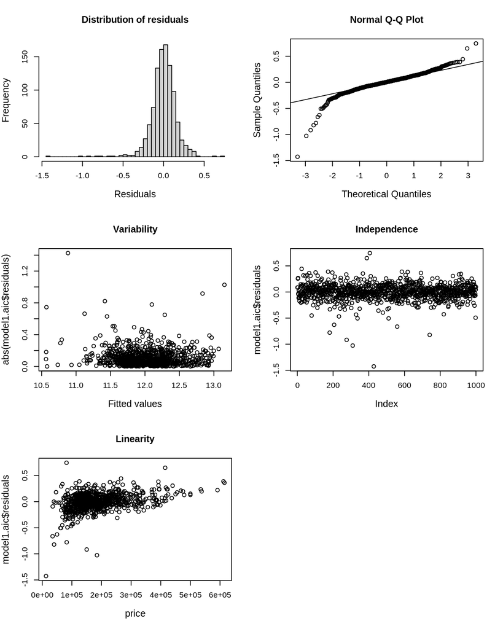

```r
par(mfrow = c(3,2), cex.lab = 1.2)
hist(model1.aic$residuals, main = "Distribution of residuals", xlab = "Residuals",
     breaks = 50, ylim = c(0,170))
qqnorm(model1.aic$residuals); qqline(model1.aic$residuals)

plot(abs(model1.aic$residuals) ~ model1.aic$fitted, xlab = "Fitted values",
     main = "Variability")

plot(model1.aic$residuals, main = "Independence")

plot(model1.aic$residuals ~ ames_train$price, xlab = "price", main = "Linearity")
```

While the residuals are centered around 0 (i.e. mean = 0), the distribution is left skewed. Therefore, there are some residuals to the left that the model fails to explain. This is further evident from the normal probability plot. It appears that the model is not adequate in explaining the whole variation.

There are extreme values at the lower as well as the higher end. However, the independence of the data is present. This model might under predict house prices at higher end and over predict prices at lower end of true house prices.

## 2.4 Initial Model RMSE

You can calculate it directly based on the model output. Be specific about the units of your RMSE (depending on whether you transformed your response variable). The value you report will be more meaningful if it is in the original units (dollars).

```r
# Model RMSE
model1.aic.rmse <- sqrt( mean( (exp(model1.aic$fitted.values) - ames_train$price )^2 ) )
model1.aic.rmse
```

```
## [1] 30506.96
```

The RMSE value of the AIC model is $30,506.96. RMSE is the square root of the mean of squared sum of residuals of the model. This value signifies how well the model agrees with the data or how small the total deviation of the data is about the regression line.

## 2.5 Overfitting

The process of building a model generally involves starting with an initial model (as you have done above), identifying its shortcomings, and adapting the model accordingly. This process may be repeated several times until the model fits the data reasonably well. However, the model may do well on training data but perform poorly out-of-sample (meaning, on a dataset other than the original training data) because the model is overly-tuned to specifically fit the training data. This is called “overfitting.” To determine whether overfitting is occurring on a model, compare the performance of a model on both in-sample and out-of-sample data sets. To look at performance of your initial model on out-of-sample data, you will use the data set `ames_test`.

```r
load("ames_test.Rdata")
```

Use your model from above to generate predictions for the housing prices in the test data set. Are the predictions significantly more accurate (compared to the actual sales prices) for the training data than the test data? Why or why not? Briefly explain how you determined that (what steps or processes did you use)?

```r
# Following results in the error "factor Neighborhood has new levels Landmrk"
# model1.aic.test.predict <- exp( predict(model1.aic, ames_test) )

# Let us count the number of observations in the ames_test data set.
which(ames_test$Neighborhood == "Landmrk")
```

```
## [1] 205
```

Our training data set does not have a level “Landmrk” for **Neighborhood** variable. However, there is one such observation in the ames_test (observation 205). We have to remove it because we are using our model to predict about a new data set. If our model does not have that particular level, it cannot be used to make predictions about such data.

```r
# Modify ames_test by removing observation 205.
ames_test <- ames_test[-205, ]

# We need to clean ames_test the same way we did for ames_train.
# Change the categorical variables that have been coded as numerical back into categorical.
ames_test$Overall.Cond <- factor(ames_test$Overall.Cond, ordered = TRUE)
ames_test$Overall.Qual <- factor(ames_test$Overall.Qual, ordered = TRUE)

# Convert all NA's of Total.Bsmt.SF and Garage.Area into 0.
ames_test$Total.Bsmt.SF <- replace_na(ames_test$Total.Bsmt.SF, 0)
ames_test$Garage.Area <- replace_na(ames_test$Garage.Area, 0)

# RMSE of test data fit.
model1.aic.test.predict <- exp(predict(model1.aic, newdata = ames_test))
model1.aic.test.rmse <- sqrt( mean( (model1.aic.test.predict - ames_test$price)^2  ) )

model1.aic.test.rmse
```

```
## [1] 26983.86
```

The determination of the performance was evaluated by comparing the RMSE values. The RMSE of the model was $30,506.96, but in the test set, it is $26,983.86. The model is more accurate to test data than the training data. There is no overfitting.

**Note to the learner:** If in real-life practice this out-of-sample analysis shows evidence that the training data fits your model a lot better than the test data, it is probably a good idea to go back and revise the model (usually by simplifying the model) to reduce this overfitting. For simplicity, we do not ask you to do this on the assignment, however.

# 3 Development of a Final Model

Now that you have developed an initial model to use as a baseline, create a final model with *at most* 20 variables to predict housing prices in Ames, IA, selecting from the full array of variables in the dataset and using any of the tools that we introduced in this specialization.

Carefully document the process that you used to come up with your final model, so that you can answer the questions below.

## 3.1 Final Model

Provide the summary table for your model.

Let us start by selecting the observations that belong to the sale condition “NormaL” as other categories might represent outliers.

```r
ames_train_normal <- ames_train %>% filter(Sale.Condition == "Normal")
```

The dependent variable is **log(price)**. Summary table for initial variables is as follows.

```r
finmod <- lm(log(price) ~ log(area) + Neighborhood + Overall.Qual + Year.Built +
               log(Garage.Area + 1) + log(Total.Bsmt.SF + 1) + log(Lot.Area) +
               Bedroom.AbvGr + Kitchen.Qual + Kitchen.AbvGr + Land.Slope +
               Lot.Shape + House.Style + Heating.QC + Central.Air + Fireplaces +
               Bldg.Type + Heating + Full.Bath + Exter.Cond,
               data = ames_train_normal)

finmod.aic <- stepAIC(finmod, trace = FALSE, k = 2)
```

Summary table for the model is as follows.

```r
summary(finmod.aic)
```

```
##
## Call:
## lm(formula = log(price) ~ log(area) + Neighborhood + Overall.Qual +
##     Year.Built + log(Total.Bsmt.SF + 1) + log(Lot.Area) + Kitchen.Qual +
##     Land.Slope + House.Style + Heating.QC + Central.Air + Fireplaces +
##     Bldg.Type + Heating + Exter.Cond, data = ames_train_normal)
##
## Residuals:
##      Min       1Q   Median       3Q      Max
## -0.64974 -0.06166  0.00261  0.06127  0.53553
##
## Coefficients:
##                          Estimate Std. Error t value Pr(>|t|)
## (Intercept)             3.3899866  0.7146073   4.744 2.50e-06 ***
## log(area)               0.4648314  0.0241938  19.213  < 2e-16 ***
## NeighborhoodBlueste     0.0040239  0.0797866   0.050 0.959790
## NeighborhoodBrDale     -0.1024367  0.0652603  -1.570 0.116907
## NeighborhoodBrkSide    -0.0169478  0.0546561  -0.310 0.756584
## NeighborhoodClearCr     0.0144644  0.0620595   0.233 0.815766
## NeighborhoodCollgCr    -0.0375068  0.0479722  -0.782 0.434549
## NeighborhoodCrawfor     0.0753857  0.0539459   1.397 0.162689
## NeighborhoodEdwards    -0.1043959  0.0501340  -2.082 0.037644 *
## NeighborhoodGilbert    -0.0762557  0.0507902  -1.501 0.133668
## NeighborhoodGreens      0.1121951  0.0713644   1.572 0.116331
## NeighborhoodGrnHill     0.4753613  0.0894153   5.316 1.39e-07 ***
## NeighborhoodIDOTRR     -0.1421382  0.0557043  -2.552 0.010915 *
## NeighborhoodMeadowV    -0.1614830  0.0547927  -2.947 0.003305 **
## NeighborhoodMitchel    -0.0208072  0.0504225  -0.413 0.679973
## NeighborhoodNAmes      -0.0385795  0.0491371  -0.785 0.432614
## NeighborhoodNoRidge     0.0635271  0.0509202   1.248 0.212566
## NeighborhoodNPkVill    -0.0097397  0.0722384  -0.135 0.892784
## NeighborhoodNridgHt     0.0688965  0.0486370   1.417 0.157023
## NeighborhoodNWAmes     -0.0293402  0.0506754  -0.579 0.562770
## NeighborhoodOldTown    -0.0694658  0.0538148  -1.291 0.197152
## NeighborhoodSawyer     -0.0369509  0.0505373  -0.731 0.464904
## NeighborhoodSawyerW    -0.0708238  0.0495351  -1.430 0.153192
## NeighborhoodSomerst     0.0427895  0.0467548   0.915 0.360381
## NeighborhoodStoneBr     0.0532098  0.0541735   0.982 0.326307
## NeighborhoodSWISU      -0.0787337  0.0617042  -1.276 0.202348
## NeighborhoodTimber      0.0037962  0.0532717   0.071 0.943208
```

[output cut: 33 more lines]

```
## Bldg.TypeTwnhs         -0.0821202  0.0315956  -2.599 0.009527 **
## Bldg.TypeTwnhsE        -0.0539327  0.0217415  -2.481 0.013329 *
## HeatingGasW             0.1735575  0.0465702   3.727 0.000208 ***
## HeatingGrav             0.0633372  0.1265164   0.501 0.616780
## HeatingOthW            -0.1102480  0.1189698  -0.927 0.354380
## HeatingWall             0.3873582  0.1244500   3.113 0.001924 **
## Exter.CondFa           -0.2205088  0.0642930  -3.430 0.000637 ***
## Exter.CondGd           -0.0548109  0.0574712  -0.954 0.340532
## Exter.CondTA           -0.0772558  0.0562880  -1.373 0.170307
## ---
## Signif. codes:  0 '***' 0.001 '**' 0.01 '*' 0.05 '.' 0.1 ' ' 1
##
## Residual standard error: 0.1081 on 765 degrees of freedom
## Multiple R-squared:  0.9264, Adjusted R-squared:  0.9198
## F-statistic: 141.5 on 68 and 765 DF,  p-value: < 2.2e-16
```

The final model has an adjusted $R^2$ of 0.9198 i.e. 92% of the variability in log(price) can be explained by the model.

AIC has dropped the variables **Lot.Shape**, **Kitchen.AbvGr**, **Bedroom.AbvGr**, **Full.Bath**, and **Garage.Area**. This is evident from the following summary.

```r
finmod.aic$anova
```

```
## Stepwise Model Path
## Analysis of Deviance Table
##
## Initial Model:
## log(price) ~ log(area) + Neighborhood + Overall.Qual + Year.Built +
##     log(Garage.Area + 1) + log(Total.Bsmt.SF + 1) + log(Lot.Area) +
##     Bedroom.AbvGr + Kitchen.Qual + Kitchen.AbvGr + Land.Slope +
##     Lot.Shape + House.Style + Heating.QC + Central.Air + Fireplaces +
##     Bldg.Type + Heating + Full.Bath + Exter.Cond
##
## Final Model:
## log(price) ~ log(area) + Neighborhood + Overall.Qual + Year.Built +
##     log(Total.Bsmt.SF + 1) + log(Lot.Area) + Kitchen.Qual + Land.Slope +
##     House.Style + Heating.QC + Central.Air + Fireplaces + Bldg.Type +
##     Heating + Exter.Cond
##
##
##                     Step Df    Deviance Resid. Df Resid. Dev       AIC
## 1                                             758   8.876969 -3636.673
## 2            - Lot.Shape  3 0.015138881       761   8.892108 -3641.252
## 3        - Kitchen.AbvGr  1 0.009059176       762   8.901167 -3642.403
## 4        - Bedroom.AbvGr  1 0.012388677       763   8.913556 -3643.243
## 5 - log(Garage.Area + 1)  1 0.014581158       764   8.928137 -3643.879
## 6            - Full.Bath  1 0.016883144       765   8.945020 -3644.304
```

The final model is:

> log(price) ~ log(area) + Neighborhood + Overall.Qual + Year.Built + log(Total.Bsmt.SF + 1) + log(Lot.Area) + Kitchen.Qual + Land.Slope + House.Style + Heating.QC + Central.Air + Fireplaces + Bldg.Type + Heating + Exter.Cond

The coefficients can be **interpreted** the usual way. For example, all else held constant, on average, the model predicts that for unit increase of **area**, the **price** increases by 0.46%.

## 3.2 Transformation

Did you decide to transform any variables? Why or why not? Explain in a few sentences.

Let us look at the distributions of numerical continuous variables.

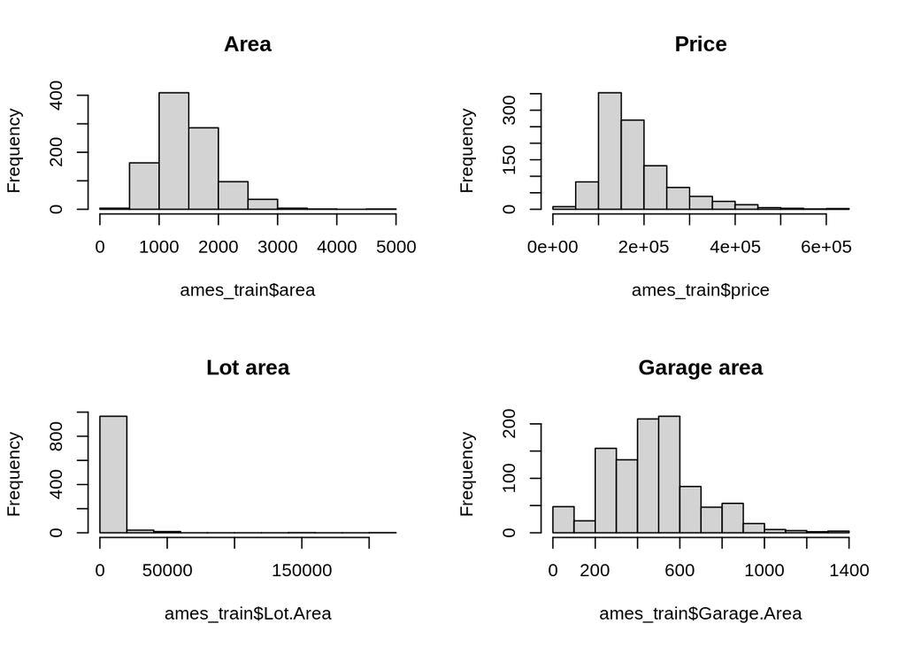

```r
par(mfrow = c(2,2), cex.lab = 1)

hist(x = ames_train$area, main = "Area")
hist(x = ames_train$price, main = "Price")
hist(x = ames_train$Lot.Area, main = "Lot area")
hist(x = ames_train$Garage.Area, main = "Garage area")
```

All these variables have right skewed distributions. It is better to take the log transforms of such variables when fitting to a linear model. This is to preserve the normality of residuals which is an expected condition of linear regression.

Therefore, the log transforms of the continuous variables were taken.

## 3.3 Variable Interaction

Did you decide to include any variable interactions? Why or why not? Explain in a few sentences.

A variable interaction occurs when one independent variable affects another independent variable, and thereby influence the dependent variable. For example, in the following model,

$$\hat{y} = b_0 + b_1x_1 + b_2x_2 + b_3 (x_1 \times x_2)$$
last term is the interaction term. $b_3$ can be interpreted as the change of slope of $x_1$ by one unit of $x_2$ or vise versa.

In the present case, I assumed that **Year.Built** and **Overall.Qual** variables would interact because it is reasonable to assume that as the construction year is new, the quality of the house would be high. The following model incorporates this idea.

```r
finmod2 <- lm(log(price) ~ log(area) + Neighborhood + Overall.Qual + Year.Built +
               log(Garage.Area + 1) + log(Total.Bsmt.SF + 1) + log(Lot.Area) + Bedroom.AbvGr +
                Kitchen.Qual + Kitchen.AbvGr + Land.Slope + Lot.Shape + House.Style +
                Heating.QC + Central.Air + Fireplaces + Bldg.Type + Heating + Full.Bath +
                Year.Built*Overall.Qual + Exter.Cond, data = ames_train_normal)

finmod.aic2 <- stepAIC(finmod2, trace = FALSE, k = 2)
finmod.aic2$anova
```

```
## Stepwise Model Path
## Analysis of Deviance Table
##
## Initial Model:
## log(price) ~ log(area) + Neighborhood + Overall.Qual + Year.Built +
##     log(Garage.Area + 1) + log(Total.Bsmt.SF + 1) + log(Lot.Area) +
##     Bedroom.AbvGr + Kitchen.Qual + Kitchen.AbvGr + Land.Slope +
##     Lot.Shape + House.Style + Heating.QC + Central.Air + Fireplaces +
##     Bldg.Type + Heating + Full.Bath + Year.Built * Overall.Qual +
##     Exter.Cond
##
## Final Model:
## log(price) ~ log(area) + Neighborhood + Overall.Qual + Year.Built +
##     log(Garage.Area + 1) + log(Total.Bsmt.SF + 1) + log(Lot.Area) +
##     Bedroom.AbvGr + Kitchen.Qual + House.Style + Heating.QC +
##     Central.Air + Fireplaces + Bldg.Type + Heating + Full.Bath +
##     Exter.Cond + Overall.Qual:Year.Built
##
##
##              Step Df   Deviance Resid. Df Resid. Dev       AIC
## 1                                     750   8.519357 -3654.966
## 2     - Lot.Shape  3 0.01364886       753   8.533006 -3659.631
## 3 - Kitchen.AbvGr  1 0.01306749       754   8.546074 -3660.355
## 4    - Land.Slope  2 0.03567476       756   8.581748 -3660.881
```

```r
summary(finmod.aic2)$adj.r.squared
```

```
## [1] 0.9221662
```

## 3.4 Variable Selection

What method did you use to select the variables you included? Why did you select the method you used? Explain in a few sentences.

Variable selection i.e. selecting the model variables was carried out using the Akaike Information Criterion (AIC) method. The AIC value includes the number of predictors as well as the maximum likelihood function. This method minimizes the AIC value by introducing a penalty for model complexity. The aim is to find the compromise between the complexity and the maximum likelihood.

## 3.5 Model Testing

How did testing the model on out-of-sample data affect whether or how you changed your model? Explain in a few sentences.

Testing data on the model helped to refine the model further. For example, some of the variables used in the model were chosen based on the response of the test data set.

# 4 Final Model Assessment

## 4.1 Final Model Residual

For your final model, create and briefly interpret an informative plot of the residuals.

Model diagnostics are given below.

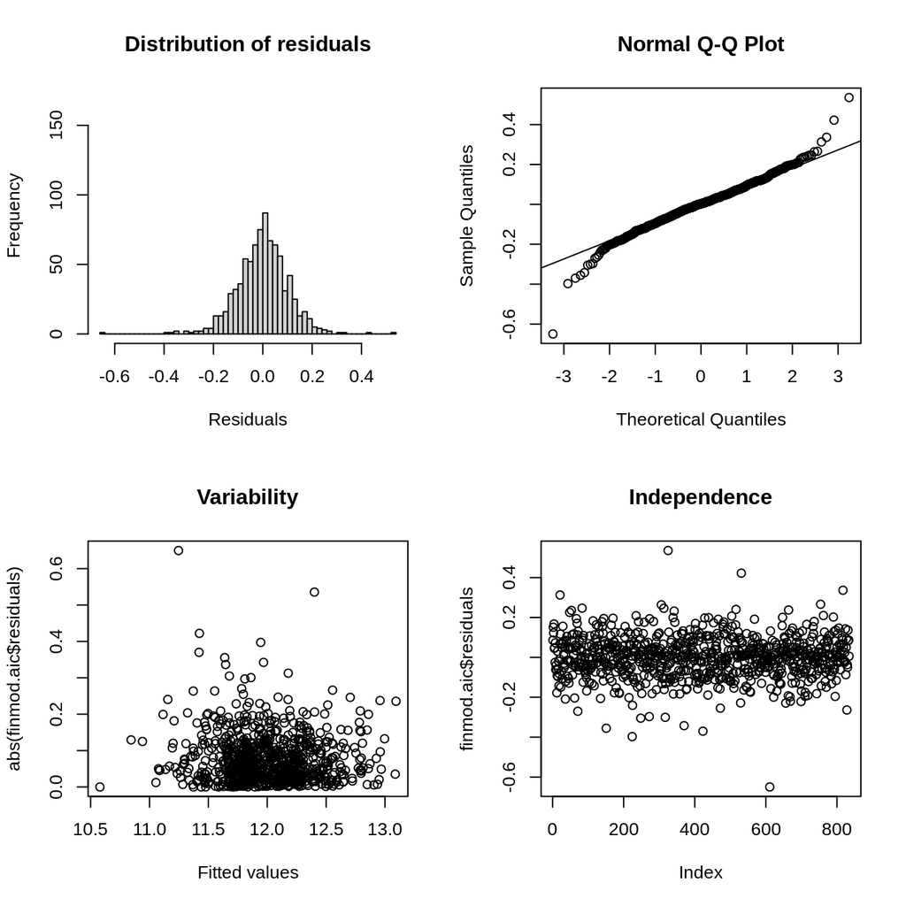

```r
par(mfrow = c(2,2), cex.lab = 1)

hist(finmod.aic$residuals, main = "Distribution of residuals", xlab = "Residuals",
     breaks = 50, ylim = c(0,170))
qqnorm(finmod.aic$residuals); qqline(finmod.aic$residuals)

plot(abs(finmod.aic$residuals) ~ finmod.aic$fitted, xlab = "Fitted values",
     main = "Variability")

plot(finmod.aic$residuals, main = "Independence")
```

The residuals are normally distributed around a mean of 0. The normal probability plot of residuals shows that the most of the points are normally distributed. The observations are independent of each other as evident in the independence plot (no time series dependence). Most residuals have a constant variability.

## 4.2 Final Model RMSE

For your final model, calculate and briefly comment on the RMSE.

Before carrying out model testing with test data, we have to clean the test data test. For instance, the training data does not have observations for certain levels of some factor variables. The model thus generated fails to provide predictions on new data that contain observations for such levels.

Level “2.5Fin” for **House.Style** variable and level “Po” of **Exter.Cond** variable are the ones that are problematic. Therefore, we have to remove observations that have these levels from the test data set.

```r
# Remove problematic observations.
ames_test_new <- ames_test[ -c(which(ames_test$House.Style == "2.5Fin" |
                                      ames_test$Exter.Cond == "Po")), ]
```

```r
# RMSE of the model.
finmod.aic.rmse = sqrt( mean( (exp(finmod.aic$fitted.values) - ames_train_normal$price)^2 ))
finmod.aic.rmse
```

```
## [1] 19655.02
```

```r
# RMSE of the model w.r.t. test data.
finmod.aic.test.predict <- predict(finmod.aic, newdata = ames_test_new)
finmod.aic.test.rmse <- sqrt( mean( (exp(finmod.aic.test.predict) - ames_test_new$price)^2 ))
finmod.aic.test.rmse
```

```
## [1] 21414.83
```

RMSE of the model for training set is $19,655.02 while that for the test data is $21,414.83. These two values are close and comparable. Therefore, we can say that the model performs well for test data.

The out of sample coverage interval is calculated as follows.

```r
finmod.aic.test.int <- exp(predict(finmod.aic, newdata = ames_test_new, interval = "prediction"))
finmod.aic.test.cp <- mean(ames_test_new$price > finmod.aic.test.int[,"lwr"] &
                              ames_test_new$price < finmod.aic.test.int[, "upr"])
finmod.aic.test.cp
```

```
## [1] 0.9544335
```

It is clear that 95.44% of the time, the true value of the **price** for test data set is contained by the 95% prediction interval of the model.

## 4.3 Final Model Evaluation

What are some strengths and weaknesses of your model?

The coverage probability is acceptable.

The RMSE value compared to the maximum house price is about 3.2%. However, with respect to the minimum, it is about 50%.

One of the weaknesses of the model is that when the test data has levels for categorical variables that the training data lacked, it fails to produce a prediction.

## 4.4 Final Model Validation

Testing your final model on a separate, validation data set is a great way to determine how your model will perform in real-life practice.

You will use the “ames_validation” dataset to do some additional assessment of your final model. Discuss your findings, be sure to mention: * What is the RMSE of your final model when applied to the validation data?  
* How does this value compare to that of the training data and/or testing data? * What percentage of the 95% predictive confidence (or credible) intervals contain the true price of the house in the validation data set?  
* From this result, does your final model properly reflect uncertainty?

```r
load("ames_validation.Rdata")
```

```r
# Clean the validation data set as usual.

# Change the categorical variables that have been coded as numerical back into categorical.
ames_validation$Overall.Cond <- factor(ames_validation$Overall.Cond, ordered = TRUE)
ames_validation$Overall.Qual <- factor(ames_validation$Overall.Qual, ordered = TRUE)

# Convert all NA's of Total.Bsmt.SF and Garage.Area into 0.
ames_validation$Total.Bsmt.SF <- replace_na(ames_validation$Total.Bsmt.SF, 0)
ames_validation$Garage.Area <- replace_na(ames_validation$Garage.Area, 0)

# Convert NA values in Garage.Qual into a separate level "NoG" meaning "No Garage".
ames_validation$Garage.Qual <- fct_explicit_na(ames_validation$Garage.Qual, na_level = "NoG")
```

Once cleaned, we have to remove the observations with levels for categorical variables that were not present in the training set.

```r
# We have to remove observations with House.Style = 2.5Fin and Heating == "Floor"
ames_validation_new <- ames_validation[ -c(which(ames_validation$House.Style == "2.5Fin" |
                                                   ames_validation$Heating == "Floor")), ]

# RMSE of the model w.r.t. test data.
finmod.aic.valid.predict <- predict(finmod.aic, newdata = ames_validation_new)
finmod.aic.valid.rmse <- sqrt( mean( (exp(finmod.aic.valid.predict) -
                                        ames_validation_new$price)^2 ))
finmod.aic.valid.rmse
```

```
## [1] 20518.91
```

The RMSE value for validation set is comparable to that obtained for testing set. However, both the testing and validation data resulted in higher RMSE values than the one obtained for training set. This implies that the model has been over-fitted. But the extent is small. It is interesting to note that the validation data set resulted a RMSE value closer to the training set than the testing set. The RMSE values are summarized below.

| Data set | RMSE |
| --- | --- |
| Training | $19,655.02 |
| Testing | $21,414.83 |
| Validation | $20,518.91 |

The coverage probability (%) for the validation data set is calculated below.

```r
finmod.aic.valid.int <- exp(predict(finmod.aic, newdata = ames_validation_new,
                                    interval = "prediction"))

finmod.aic.valid.cp <- mean(ames_validation_new$price > finmod.aic.valid.int[,"lwr"] &
                              ames_validation_new$price < finmod.aic.valid.int[, "upr"])
finmod.aic.valid.cp
```

```
## [1] 0.9366755
```

About 94% of the time, the true value of the **price** for validation data set is contained by the 95% prediction interval of the model. It can be concluded that the model captures and expresses the uncertainty of the validation data set to an agreeable extent.

**Discussion of under and over valued houses:**

This can be assessed by looking at the raw residuals and comparing it with true house prices.

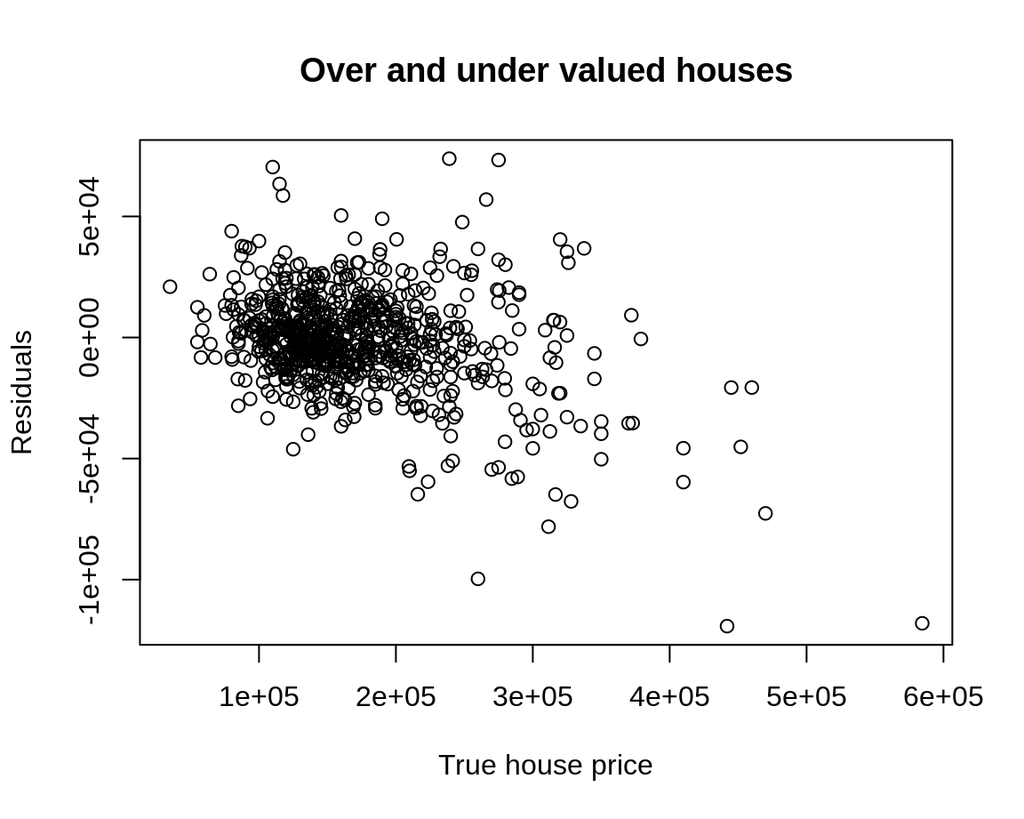

```r
validation.res = exp(finmod.aic.valid.predict) - ames_validation_new$price
plot(y = validation.res, x= ames_validation_new$price,
     xlab = "True house price", ylab = "Residuals", main = "Over and under valued houses")
```

It appears that at higher end of the house prices, the model under values the price i.e. negative residuals. This is clear from looking at true house prices above $400,000 in the above plot.

The tendency to over value prices at lower end is not as severe as the above mentioned case.

# 5 Conclusion

Provide a brief summary of your results, and a brief discussion of what you have learned about the data and your model.

The model has a good predictive power of adjusted $R^2$ of 0.9198 i.e. 92% of the variability of the data can be explained by the mode. The rest of the variability cannot be explained by the mode. This can be due to the natural random variations. Of all the variables, **area**, **Year.Built**, **Total.Bsmt.SF**, **Lot.Area** are the most significant numerical predictors. The residuals of the model obey all four criteria required for linear regression.

Even though the variable **neighborhood** was predicted to be a good predictor by the EDA as well as the model selection, according to the AIC output, only a few levels are significant based on the P-value.

One of the issues is the tendency of under valuing prices at high end of the market.

I wanted to carry out model selection using Bayesian Model Averaging (BMA) using `BAS` package. However, `bas.lm` hanged when the variable **Neighborhood** was included in the model. As I was unable to solve the issue (even using the discussion forums), I had to resort to `AIC` only.